# Tugas Praktikum MPDW Minggu 2

Muhammad Farhan Adeva - G1401211062

2023-09-09

#all Library

```r
library(TTR)
library(forecast)
library(lmtest)
library(dplyr)
library(orcutt)
library(HoRM)
```

```r
library(ggplot2)
library(corrplot)
library("SciViews")
```

#Input data

```r
library('rio')
data <- import("https://raw.githubusercontent.com/Adevaaaa/MPDW/main/Pertemuan%202/Data/Data_Tugas_Praktikum2.csv")
```

```r
#Menamai Kolom
high <- data$High
low <- data$Low
close <- data$Close
Volume <- data$Volume
open <- data$Open
```

```r
#Melihat timeseries
high.ts <- ts(high)
low.ts <- ts(low)
close.ts <- ts(close)
open.ts <- ts(open)
```

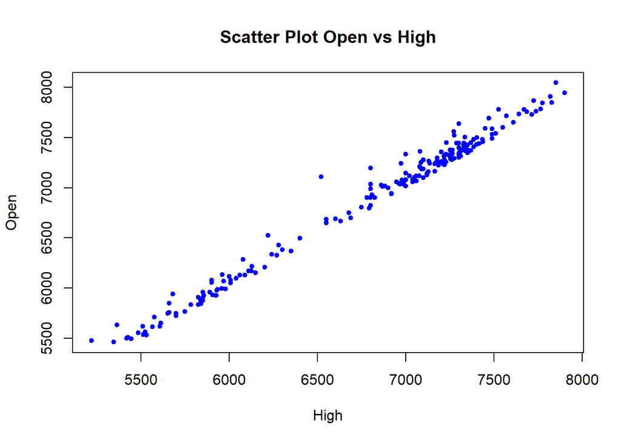

```r
# scatter plot close vs high
plot(open,high, pch = 20, col = "blue",
     main = "Scatter Plot Open vs High",
     xlab = "High",
     ylab = "Open")
```

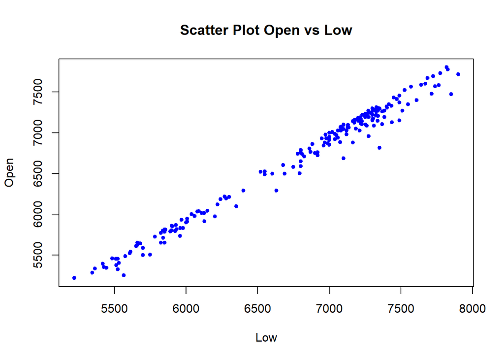

```r
# scatter plot close vs low
plot(open,low, pch = 20, col = "blue",
     main = "Scatter Plot Open vs Low",
     xlab = "Low",
     ylab = "Open")
```

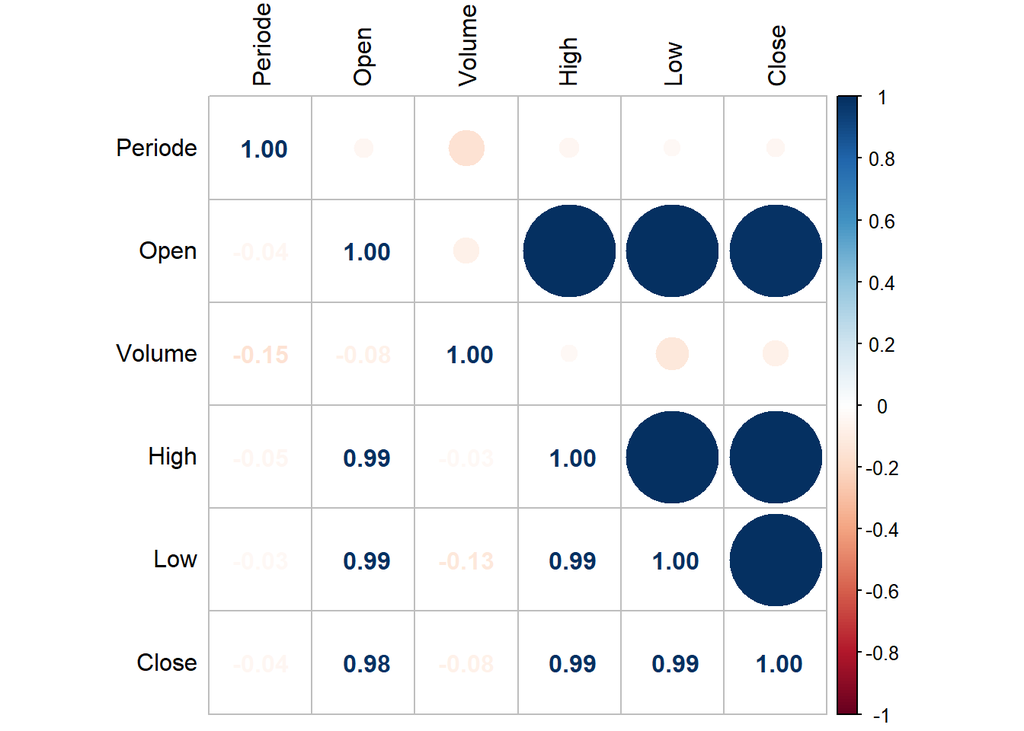

```r
# Cek Korelasi
matriks <- cor(data)
corrplot.mixed(matriks, upper = 'circle', lower = 'number', order = "original",
               tl.col="black", tl.pos = "lt",diag = 'l',
               number.digits=2, number.cex=1)
```

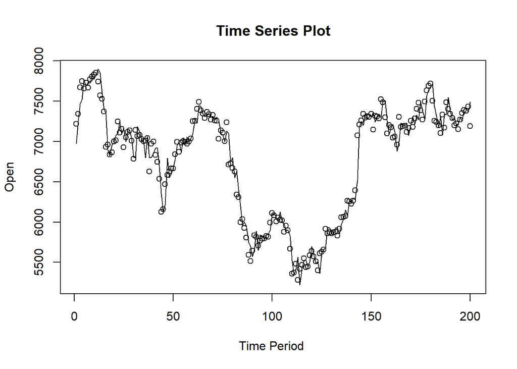

```r
# Plot time series
## CLose
ts.plot(open.ts, xlab="Time Period ", ylab="Open",
        main = "Time Series Plot")
points(close.ts)
```

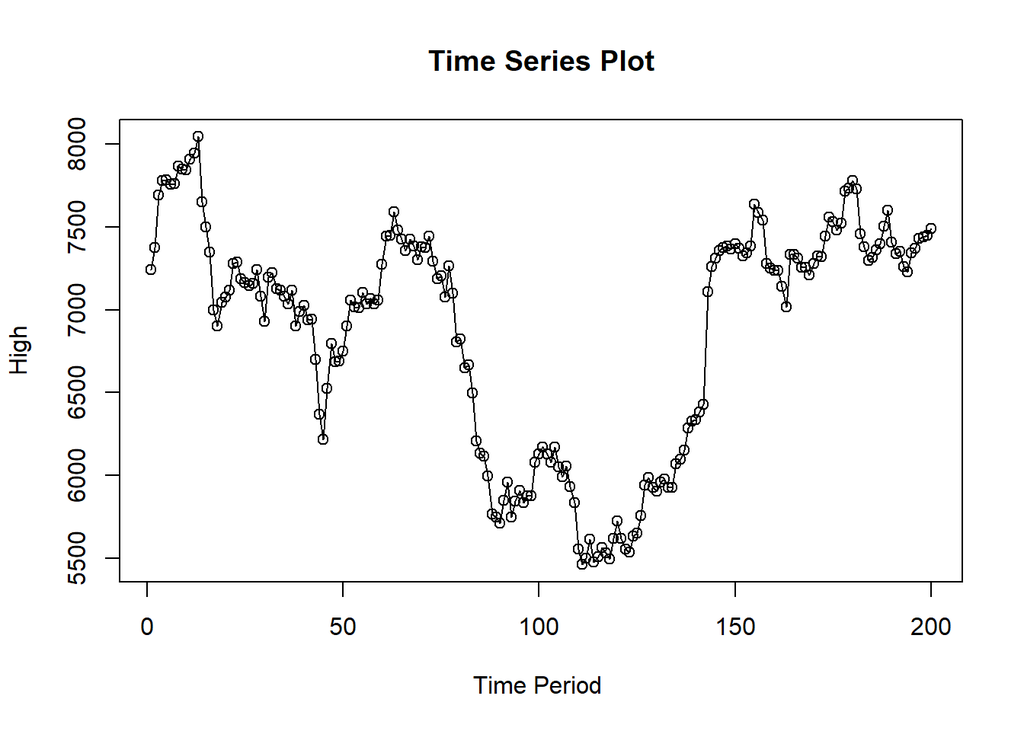

```r
## High
ts.plot(high.ts, xlab="Time Period ", ylab="High",
        main = "Time Series Plot")
points(high.ts)
```

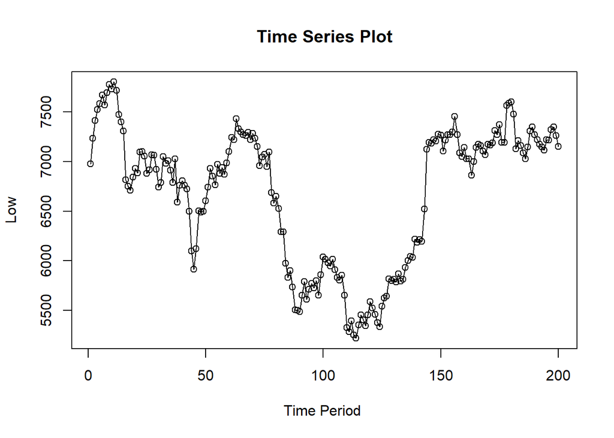

```r
## Low
ts.plot(low.ts, xlab="Time Period ", ylab="Low",
        main = "Time Series Plot")
points(low.ts)
```

```r
modelwan <- lm(Volume~close+open+high+low)
summary(modelwan)
```

```
##
## Call:
## lm(formula = Volume ~ close + open + high + low)
##
## Residuals:
##      Min       1Q   Median       3Q      Max
## -1379160  -217987   -54409   147472  2587775
##
## Coefficients:
##             Estimate Std. Error t value Pr(>|t|)
## (Intercept) 943915.2   330035.2   2.860   0.0047 **
## close         -127.0      788.4  -0.161   0.8722
## open          -263.7      729.2  -0.362   0.7180
## high          6492.2      831.5   7.808 3.48e-13 ***
## low          -6223.0      783.0  -7.948 1.49e-13 ***
## ---
## Signif. codes:  0 '***' 0.001 '**' 0.01 '*' 0.05 '.' 0.1 ' ' 1
##
## Residual standard error: 462300 on 195 degrees of freedom
## Multiple R-squared:  0.592,  Adjusted R-squared:  0.5836
## F-statistic: 70.72 on 4 and 195 DF,  p-value: < 2.2e-16
```

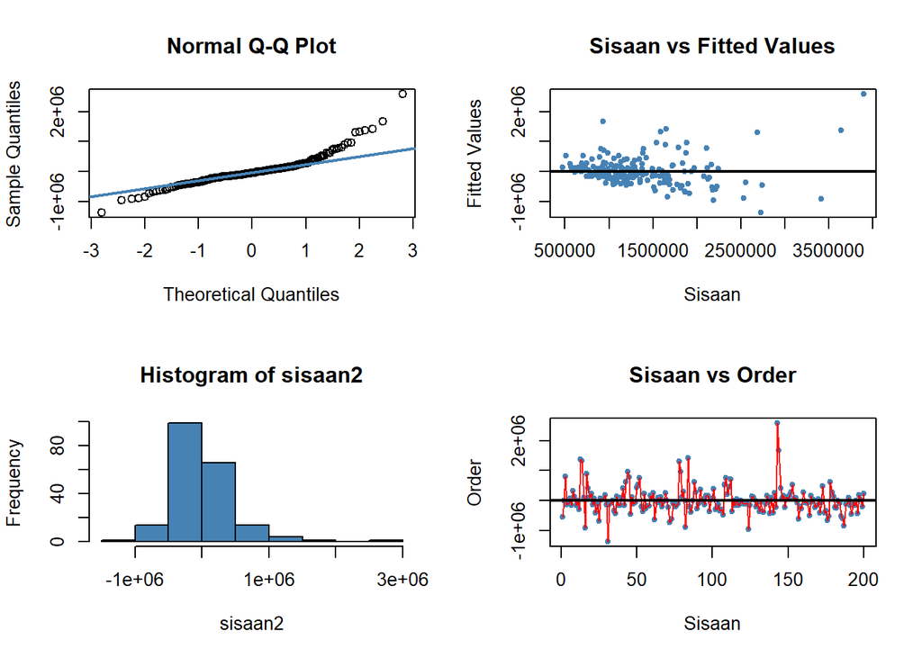

```r
#sisaan dan fitted value
sisaan2<- residuals(modelwan)
fitValue2<- predict(modelwan)

#Diagnostik dengan eksploratif
par(mfrow = c(2,2))
qqnorm(sisaan2)
qqline(sisaan2, col = "steelblue", lwd = 2)
plot(fitValue2, sisaan2, col = "steelblue", pch = 20, xlab = "Sisaan", ylab = "Fitted Values", main = "Sisaan vs Fitted Values")
abline(a = 0, b = 0, lwd = 2)
hist(sisaan2, col = "steelblue")
plot(seq(1,200,1), sisaan2, col = "steelblue", pch = 20, xlab = "Sisaan", ylab = "Order", main = "Sisaan vs Order")
lines(seq(1,200,1), sisaan2, col = "red")
abline(a = 0, b = 0, lwd = 2)
```

Dikarenakan data tersebut secara visualisasi tidak normal sehingga dilakukan transformasi dengan 1/x didapatkan hasil selanjutnya

```r
closebaru<- 1/(close)
openbaru <- 1/(open)
Volumebaru <- 1/(Volume)
highbaru <- 1/(high)
lowbaru <- 1/(low)
modelwanwan <- lm(Volumebaru~closebaru+openbaru+highbaru+lowbaru)
summary(modelwanwan)
```

```
##
## Call:
## lm(formula = Volumebaru ~ closebaru + openbaru + highbaru + lowbaru)
##
## Residuals:
##        Min         1Q     Median         3Q        Max
## -7.031e-07 -1.683e-07 -1.724e-08  1.635e-07  6.647e-07
##
## Coefficients:
##               Estimate Std. Error t value Pr(>|t|)
## (Intercept)  1.020e-06  1.635e-07   6.239 2.68e-09 ***
## closebaru   -8.118e-03  1.825e-02  -0.445    0.657
## openbaru    -2.240e-03  1.721e-02  -0.130    0.897
## highbaru     1.308e-01  1.981e-02   6.604 3.71e-10 ***
## lowbaru     -1.176e-01  1.815e-02  -6.483 7.21e-10 ***
## ---
## Signif. codes:  0 '***' 0.001 '**' 0.01 '*' 0.05 '.' 0.1 ' ' 1
##
## Residual standard error: 2.457e-07 on 195 degrees of freedom
## Multiple R-squared:  0.5006, Adjusted R-squared:  0.4904
## F-statistic: 48.87 on 4 and 195 DF,  p-value: < 2.2e-16
```

Model yang dihasilkan adalah
$$y_i=1.02*10^-6-8.12*10^-3x1_t-2.24*10^-3x2_t+1.31*10^-1x3_t-1.17*10^-1x4_t$$
Berdasarkan ringkasan model dapat diketahui bahwa hasil uji F memiliki *p-value* < $\alpha$ (5%). Artinya, minimal terdapat satu variabel yang berpengaruh nyata terhadap model. Hasil uji-t parsial parameter regresi, yaitu koefisien regresi juga menunjukkan hal yang sama, yaitu memiliki *p-value* < $\alpha$ (5%) sehingga nyata dalam taraf 5% untuk high dan low, untuk open dan close tidak *p-value* > $\alpha$ (5%). Selanjutnya dapat dilihat juga nilai $R^2=0.5006$. Artinya, sebesar 50.06% keragaman nilai Volume dapat dijelaskan oleh peubah x. Hasil ini menunjukkan hasil yang bagus, seolah mendapatkan hasil terbaik. Namun, kita perlu melakukan uji terhadap sisaannya seperti berikut ini.

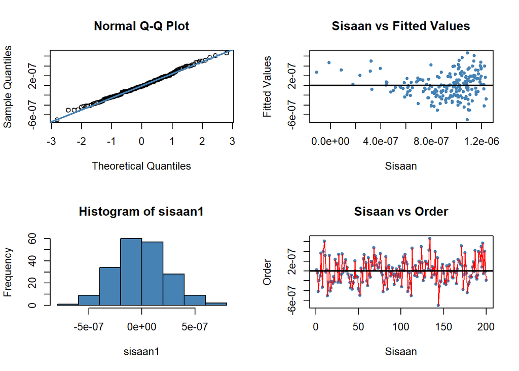

```r
#sisaan dan fitted value
sisaan1<- residuals(modelwanwan)
fitValue1<- predict(modelwanwan)

#Diagnostik dengan eksploratif
par(mfrow = c(2,2))
qqnorm(sisaan1)
qqline(sisaan1, col = "steelblue", lwd = 2)
plot(fitValue1, sisaan1, col = "steelblue", pch = 20, xlab = "Sisaan", ylab = "Fitted Values", main = "Sisaan vs Fitted Values")
abline(a = 0, b = 0, lwd = 2)
hist(sisaan1, col = "steelblue")
plot(seq(1,200,1), sisaan1, col = "steelblue", pch = 20, xlab = "Sisaan", ylab = "Order", main = "Sisaan vs Order")
lines(seq(1,200,1), sisaan1, col = "red")
abline(a = 0, b = 0, lwd = 2)
```

Secara visualisasi data tersebut terlihat normal sehingga dilakukan pengujian testnya

```r
#H0: sisaan mengikuti sebaran normal
#H1: sisaan tidak mengikuti sebaran normal
shapiro.test(sisaan1)
```

```
##
##  Shapiro-Wilk normality test
##
## data:  sisaan1
## W = 0.99565, p-value = 0.8405
```

```r
ks.test(sisaan1, "pnorm", mean=mean(sisaan1), sd=sd(sisaan1))
```

```
##
##  Asymptotic one-sample Kolmogorov-Smirnov test
##
## data:  sisaan1
## D = 0.035295, p-value = 0.9645
## alternative hypothesis: two-sided
```

setelah dilakukan pengujian, didapatkan hasil melalui 2 test yaitu test Shapiro didapatkan hasil tak tolak H0 maka data tersebut normal dan begitu juga kolmogorov-Smirnov tak tolak H0

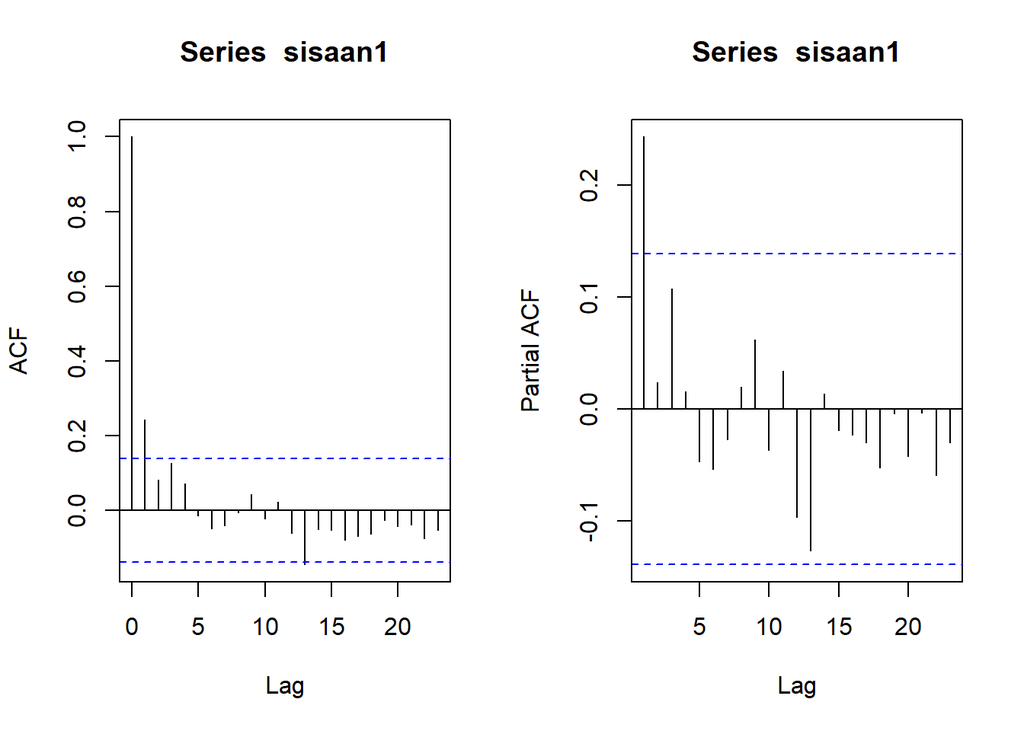

```r
par(mfrow = c(1,2))
acf(sisaan1)
pacf(sisaan1)
```

Berdasarkan plot ACF dan PACF, terlihat terdapat data yang berada diluar rentang batas sehingga ada yang signifikan. Namun, untuk lebih memastikan akan dilakukan uji formal dengan uji Durbin Watson.

```r
#H0: tidak ada autokorelasi
#H1: ada autokorelasi
dwtest(modelwanwan)
```

```
##
##  Durbin-Watson test
##
## data:  modelwanwan
## DW = 1.511, p-value = 0.0001876
## alternative hypothesis: true autocorrelation is greater than 0
```

```r
#Penanganan Autokorelasi Cochrane-Orcutt
#H0: tidak ada autokorelasi
#H1: ada autokorelasi
modelCOwanwan<-cochrane.orcutt(modelwanwan)
modelCOwanwan
```

```
## Cochrane-orcutt estimation for first order autocorrelation
##
## Call:
## lm(formula = Volumebaru ~ closebaru + openbaru + highbaru + lowbaru)
##
##  number of interaction: 13
##  rho 0.317797
##
## Durbin-Watson statistic
## (original):    1.51097 , p-value: 1.876e-04
## (transformed): 2.01900 , p-value: 5.47e-01
##
##  coefficients:
## (Intercept)   closebaru    openbaru    highbaru     lowbaru
##    0.000001   -0.007985   -0.005712    0.112386   -0.096626
```

```r
#Rho optimum
rhowanwan<- modelCOwanwan$rho
rhowanwan
```

```
## [1] 0.3177966
```

#Transformasi Manual

```r
#Transformasi Manual
volumebaru.trans<- Volumebaru[-1]-Volumebaru[-200]*rhowanwan
highbaru.trans<- highbaru[-1]-highbaru[-200]*rhowanwan
lowbaru.trans<- lowbaru[-1]-lowbaru[-200]*rhowanwan
openbaru.trans<- openbaru[-1]-openbaru[-200]*rhowanwan
closebaru.trans<- closebaru[-1]-closebaru[-200]*rhowanwan
modelCOmanualwanwan<- lm(volumebaru.trans~highbaru.trans+lowbaru.trans+openbaru.trans+closebaru.trans)
summary(modelCOmanualwanwan)
```

```
##
## Call:
## lm(formula = volumebaru.trans ~ highbaru.trans + lowbaru.trans +
##     openbaru.trans + closebaru.trans)
##
## Residuals:
##        Min         1Q     Median         3Q        Max
## -7.156e-07 -1.479e-07 -4.360e-08  1.464e-07  5.585e-07
##
## Coefficients:
##                   Estimate Std. Error t value Pr(>|t|)
## (Intercept)      7.136e-07  1.544e-07   4.620 6.98e-06 ***
## highbaru.trans   1.124e-01  1.839e-02   6.113 5.28e-09 ***
## lowbaru.trans   -9.663e-02  1.687e-02  -5.729 3.81e-08 ***
## openbaru.trans  -5.712e-03  1.588e-02  -0.360    0.720
## closebaru.trans -7.985e-03  1.645e-02  -0.485    0.628
## ---
## Signif. codes:  0 '***' 0.001 '**' 0.01 '*' 0.05 '.' 0.1 ' ' 1
##
## Residual standard error: 2.366e-07 on 194 degrees of freedom
## Multiple R-squared:  0.421,  Adjusted R-squared:  0.4091
## F-statistic: 35.26 on 4 and 194 DF,  p-value: < 2.2e-16
```

```r
#Mencari Penduga Koefisien Regresi setelah Transformasi ke Persamaan Awal
b0bintang1 <- modelCOmanualwanwan$coefficients[1]
b0.1<- b0bintang1/(1-rhowanwan)
b1.1 <- modelCOmanualwanwan$coefficients[2]
b2.1 <- modelCOmanualwanwan$coefficients[3]
b3.1 <- modelCOmanualwanwan$coefficients[4]
b4.1 <- modelCOmanualwanwan$coefficients[5]
b0.1
```

```
##  (Intercept)
## 1.045991e-06
```

```r
b1.1
```

```
## highbaru.trans
##      0.1123857
```

```r
b2.1
```

```
## lowbaru.trans
##    -0.0966262
```

```r
b3.1
```

```
## openbaru.trans
##   -0.005711565
```

```r
b4.1
```

```
## closebaru.trans
##    -0.007985313
```

```r
hildreth.lu.func<- function(r, model){
  x1 <- model.matrix(model)[,2]
  x2 <- model.matrix(model)[,3]
  x3 <- model.matrix(model)[,4]
  x4 <- model.matrix(model)[,5]
  y <- model.response(model.frame(model))
  n <- length(y)
  t <- 2:n
  y <- y[t]-r*y[t-1]
  x1 <- x1[t]-r*x1[t-1]
  x2 <- x2[t]-r*x2[t-1]
  x3 <- x3[t]-r*x3[t-1]
  x4 <- x4[t]-r*x4[t-1]

  return(lm(y~x1+x2+x3+x4))
}

#Pencariab rho yang meminimumkan SSE
r1 <- c(seq(0.1,0.9, by= 0.1))
tab1 <- data.frame("rho" = r1, "SSE" = sapply(r1, function(i){deviance(hildreth.lu.func(i, modelwanwan))}))
tab1
```

```
##   rho          SSE
## 1 0.1 1.129077e-11
## 2 0.2 1.098577e-11
## 3 0.3 1.086011e-11
## 4 0.4 1.092243e-11
## 5 0.5 1.118580e-11
## 6 0.6 1.166419e-11
## 7 0.7 1.236839e-11
## 8 0.8 1.330077e-11
## 9 0.9 1.445348e-11
```

Pertama-tama akan dicari di mana kira-kira $ρ$ yang menghasilkan SSE minimum. Pada hasil di atas terlihat $ρ$ minimum ketika 0.3. Namun, hasil tersebut masih kurang teliti sehingga akan dicari kembali $ρ$ yang lebih optimum dengan ketelitian yang lebih. Jika sebelumnya jarak antar $ρ$ yang dicari adalah 0.1, kali ini jarak antar $ρ$ adalah 0.001 dan dilakukan pada selang 0.2 sampai dengan 0.6.

```r
rOpt1<- seq(0.2,0.6, by= 0.001)
tabOpt1 <- data.frame("rho" = rOpt1, "SSE" = sapply(rOpt1, function(i){deviance(hildreth.lu.func(i, modelwanwan))}))
head(tabOpt1[order(tabOpt1$SSE),])
```

```
##       rho          SSE
## 119 0.318 1.085712e-11
## 118 0.317 1.085712e-11
## 120 0.319 1.085713e-11
## 117 0.316 1.085715e-11
## 121 0.320 1.085716e-11
## 116 0.315 1.085719e-11
```

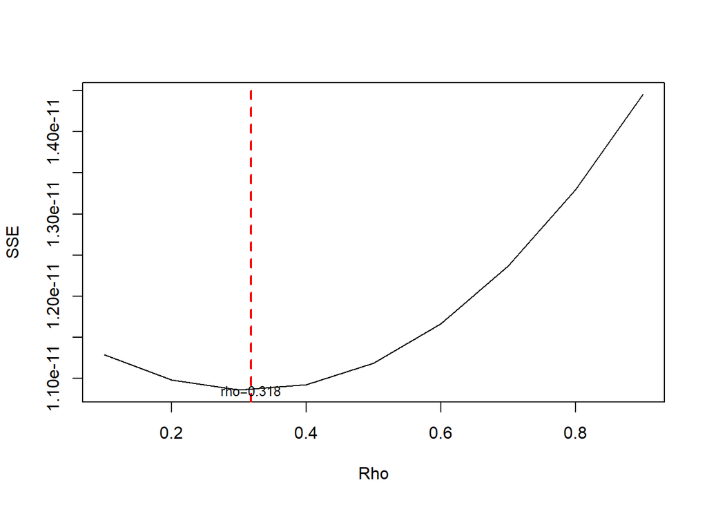

```r
#Grafik SSE optimum
par(mfrow = c(1,1))
plot(tab1$SSE ~ tab1$rho , type = "l", xlab = "Rho", ylab = "SSE")
abline(v = tabOpt1[tabOpt1$SSE==min(tabOpt1$SSE),"rho"], lty = 2, col="red",lwd=2)
text(x=0.318, y=1.085712*10^-11 , labels = "rho=0.318", cex = 0.8)
```

Perhitungan yang dilakukan aplikasi `R` menunjukkan bahwa nilai $ρ$ optimum, yaitu saat SSE terkecil terdapat pada nilai $ρ=0.318$. Hal tersebut juga ditunjukkan pada plot. Selanjutnya, model dapat didapatkan dengan mengevaluasi nilai $ρ$ ke dalam fungsi `hildreth.lu.func`, serta dilanjutkan dengan pengujian autokorelasi dengan uji Durbin-Watson. Namun, setelah pengecekan tersebut tidak lupa koefisien regresi tersebut digunakan untuk transformasi balik. Persamaan hasil transformasi itulah yang menjadi persamaan sesungguhnya.

```r
#Model terbaik
modelHLwanwan <- hildreth.lu.func(0.318, modelwanwan)
summary(modelHLwanwan)
```

```
##
## Call:
## lm(formula = y ~ x1 + x2 + x3 + x4)
##
## Residuals:
##        Min         1Q     Median         3Q        Max
## -7.156e-07 -1.479e-07 -4.367e-08  1.463e-07  5.584e-07
##
## Coefficients:
##               Estimate Std. Error t value Pr(>|t|)
## (Intercept)  7.134e-07  1.544e-07   4.619 7.02e-06 ***
## x1          -7.985e-03  1.645e-02  -0.485    0.628
## x2          -5.714e-03  1.588e-02  -0.360    0.719
## x3           1.124e-01  1.838e-02   6.113 5.28e-09 ***
## x4          -9.661e-02  1.687e-02  -5.728 3.82e-08 ***
## ---
## Signif. codes:  0 '***' 0.001 '**' 0.01 '*' 0.05 '.' 0.1 ' ' 1
##
## Residual standard error: 2.366e-07 on 194 degrees of freedom
## Multiple R-squared:  0.4209, Adjusted R-squared:  0.409
## F-statistic: 35.26 on 4 and 194 DF,  p-value: < 2.2e-16
```

```r
#Transformasi Balik
cat("y = ", coef(modelHLwanwan)[1]/(1-0.318), coef(modelHLwanwan)[2],"x1",coef(modelHLwanwan)[3],"x2",'+',coef(modelHLwanwan)[4],'x3',coef(modelHLwanwan)[5],'x4' ,sep = "")
```

```
## y = 1.045987e-06-0.007985115x1-0.005713609x2+0.1123746x3-0.09661358x4
```

Setelah dilakukan tranformasi balik, didapatkan model dengan metode Hildreth-Lu sebagai berikut.
$$y_i=y =
1.045987e-06-0.007985115x1_t-0.005713609x2_t+0.1123746x3_t-0.09661358x4$$

```r
#Deteksi autokorelasi
dwtest(modelHLwanwan)
```

```
##
##  Durbin-Watson test
##
## data:  modelHLwanwan
## DW = 2.0193, p-value = 0.5479
## alternative hypothesis: true autocorrelation is greater than 0
```

Hasil uji Durbin-Watson juga menunjukkan H *p-value* sebesar $0.5479$, di mana *p-value* > $\alpha$=5%. Artinya tak tolak $H_0$ atau belum cukup bukti menyatakan bahwa ada autokorelasi dalam data nilai Volume dengan metode Hildreth-Lu pada taraf nyata 5%.

```r
sseModelawal1 <- anova(modelwanwan)$`Sum Sq`[c(-1,-2)]
sseModelCO1 <- anova(modelCOmanualwanwan)$`Sum Sq`[c(-1,-2)]
sseModelHL1 <- anova(modelHLwanwan)$`Sum Sq`[c(-1)]
mseModelawal1 <- sseModelawal1/length(Volumebaru)
mseModelCO1 <- sseModelCO1/length(Volumebaru)
mseModelHL1 <- sseModelHL1/length(Volumebaru)
akurasi1 <- matrix(c(sseModelawal1,sseModelCO1,sseModelHL1,
                    mseModelawal1,mseModelCO1,mseModelHL1),nrow=2,ncol=3,byrow = T)
colnames(akurasi1) <- c("Model Awal", "Model Cochrane-Orcutt", "Model Hildreth-Lu")
row.names(akurasi1) <- c("SSE","MSE")
akurasi1
```

```
##       Model Awal Model Cochrane-Orcutt Model Hildreth-Lu
## SSE 8.639298e-12          2.537490e-12      1.177354e-11
## MSE 5.863935e-17          1.318614e-14      1.085712e-11
```

# Simpulan